# Supervised Learning Project

#### (Naveen Pete, PGP-AIML Online August 20-A)

## Data Description

The file Bank.xls contains data on 5000 customers. The data include customer demographic information (age, income, etc.), the customer's relationship with the bank (mortgage, securities account, etc.), and the customer response to the last personal loan campaign (Personal Loan). Among these 5000 customers, only 480 (= 9.6%) accepted the personal loan that was offered to them in the earlier campaign.

## Domain

Banking

## Context

This case is about a bank (Thera Bank) whose management wants to explore ways of converting its liability customers to personal loan customers (while retaining them as depositors). A campaign that the bank ran last year for liability customers showed a healthy conversion rate of over 9% success. This has encouraged the retail marketing department to devise campaigns with better target marketing to increase the success ratio with minimal budget.

## Attribute Information

- **ID:** Customer ID
- **Age:** Customer's age in completed years
- **Experience:** #years of professional experience
- **Income:** Annual income of the customer (\$000)
- **ZIP Code:** Home Address ZIP code
- **Family:** Family size of the customer
- **CCAvg:** Avg. spending on credit cards per month (\$000)
- **Education:** Education Level - 1. Undergrad, 2. Graduate, 3. Advanced/Professional
- **Mortgage:** Value of house mortgage if any (\$000)
- **Personal Loan:** Did this customer accept the personal loan offered in the last campaign?
- **Securities Account:** Does the customer have a securities account with the bank?
- **CD Account:** Does the customer have a certificate of deposit (CD) account with the bank?
- **Online:** Does the customer use internet banking facilities?
- **Credit card:** Does the customer use a credit card issued by Thera Bank?

## Learning Outcomes

- Exploratory Data Analysis
- Preparing the data to train a model
- Training and making predictions using a classification model
- Model evaluation

## Objective

The classification goal is to predict the likelihood of a liability customer buying personal loans.

### Import the necessary libraries

```python
# Libraries needed for scientific computation, data analysis and manipulation
import numpy as np
import pandas as pd

# Libraries needed for statistical data visualization
from matplotlib import pyplot as plt
import seaborn as sns

sns.set_style('whitegrid')
%matplotlib inline
```

## 1. Read the column description and ensure you understand each attribute well

```python
# Initialize dataframe with insurance dataset
bank_master_df = pd.read_csv("Bank_Personal_Loan_Modelling.csv")
```

```python
bank_master_df.head(10)
```

|  | ID | Age | Experience | Income | ZIP Code | Family | CCAvg | Education | Mortgage | Personal Loan | Securities Account | CD Account | Online | CreditCard |
| --- | --- | --- | --- | --- | --- | --- | --- | --- | --- | --- | --- | --- | --- | --- |
| 0 | 1 | 25 | 1 | 49 | 91107 | 4 | 1.6 | 1 | 0 | 0 | 1 | 0 | 0 | 0 |
| 1 | 2 | 45 | 19 | 34 | 90089 | 3 | 1.5 | 1 | 0 | 0 | 1 | 0 | 0 | 0 |
| 2 | 3 | 39 | 15 | 11 | 94720 | 1 | 1.0 | 1 | 0 | 0 | 0 | 0 | 0 | 0 |
| 3 | 4 | 35 | 9 | 100 | 94112 | 1 | 2.7 | 2 | 0 | 0 | 0 | 0 | 0 | 0 |
| 4 | 5 | 35 | 8 | 45 | 91330 | 4 | 1.0 | 2 | 0 | 0 | 0 | 0 | 0 | 1 |
| 5 | 6 | 37 | 13 | 29 | 92121 | 4 | 0.4 | 2 | 155 | 0 | 0 | 0 | 1 | 0 |
| 6 | 7 | 53 | 27 | 72 | 91711 | 2 | 1.5 | 2 | 0 | 0 | 0 | 0 | 1 | 0 |
| 7 | 8 | 50 | 24 | 22 | 93943 | 1 | 0.3 | 3 | 0 | 0 | 0 | 0 | 0 | 1 |
| 8 | 9 | 35 | 10 | 81 | 90089 | 3 | 0.6 | 2 | 104 | 0 | 0 | 0 | 1 | 0 |
| 9 | 10 | 34 | 9 | 180 | 93023 | 1 | 8.9 | 3 | 0 | 1 | 0 | 0 | 0 | 0 |

```python
row_count, column_count = bank_master_df.shape

print(f'No. of rows: {row_count}')
print(f'No. of columns: {column_count}')
```

```
No. of rows: 5000
No. of columns: 14
```

```python
bank_master_df.info()
```

```
<class 'pandas.core.frame.DataFrame'>
RangeIndex: 5000 entries, 0 to 4999
Data columns (total 14 columns):
 #   Column              Non-Null Count  Dtype
---  ------              --------------  -----
 0   ID                  5000 non-null   int64
 1   Age                 5000 non-null   int64
 2   Experience          5000 non-null   int64
 3   Income              5000 non-null   int64
 4   ZIP Code            5000 non-null   int64
 5   Family              5000 non-null   int64
 6   CCAvg               5000 non-null   float64
 7   Education           5000 non-null   int64
 8   Mortgage            5000 non-null   int64
 9   Personal Loan       5000 non-null   int64
 10  Securities Account  5000 non-null   int64
 11  CD Account          5000 non-null   int64
 12  Online              5000 non-null   int64
 13  CreditCard          5000 non-null   int64
dtypes: float64(1), int64(13)
memory usage: 547.0 KB
```

**Observations**

- There are 5000 rows and 14 columns in the dataset
- All the columns are numerical

### Checking the presence of missing values

```python
bank_master_df.isnull().apply(pd.value_counts)
```

|  | ID | Age | Experience | Income | ZIP Code | Family | CCAvg | Education | Mortgage | Personal Loan | Securities Account | CD Account | Online | CreditCard |
| --- | --- | --- | --- | --- | --- | --- | --- | --- | --- | --- | --- | --- | --- | --- |
| False | 5000 | 5000 | 5000 | 5000 | 5000 | 5000 | 5000 | 5000 | 5000 | 5000 | 5000 | 5000 | 5000 | 5000 |

```python
bank_master_df.isnull().sum()
```

```
ID                    0
Age                   0
Experience            0
Income                0
ZIP Code              0
Family                0
CCAvg                 0
Education             0
Mortgage              0
Personal Loan         0
Securities Account    0
CD Account            0
Online                0
CreditCard            0
dtype: int64
```

**Observations**

- There are no missing / null values in the dataset. All rows and colums contain data

## 2. Study the data distribution in each attribute, share your findings (15 marks)

```python
bank_master_df.describe().transpose()
```

|  | count | mean | std | min | 25% | 50% | 75% | max |
| --- | --- | --- | --- | --- | --- | --- | --- | --- |
| ID | 5000.0 | 2500.500000 | 1443.520003 | 1.0 | 1250.75 | 2500.5 | 3750.25 | 5000.0 |
| Age | 5000.0 | 45.338400 | 11.463166 | 23.0 | 35.00 | 45.0 | 55.00 | 67.0 |
| Experience | 5000.0 | 20.104600 | 11.467954 | -3.0 | 10.00 | 20.0 | 30.00 | 43.0 |
| Income | 5000.0 | 73.774200 | 46.033729 | 8.0 | 39.00 | 64.0 | 98.00 | 224.0 |
| ZIP Code | 5000.0 | 93152.503000 | 2121.852197 | 9307.0 | 91911.00 | 93437.0 | 94608.00 | 96651.0 |
| Family | 5000.0 | 2.396400 | 1.147663 | 1.0 | 1.00 | 2.0 | 3.00 | 4.0 |
| CCAvg | 5000.0 | 1.937938 | 1.747659 | 0.0 | 0.70 | 1.5 | 2.50 | 10.0 |
| Education | 5000.0 | 1.881000 | 0.839869 | 1.0 | 1.00 | 2.0 | 3.00 | 3.0 |
| Mortgage | 5000.0 | 56.498800 | 101.713802 | 0.0 | 0.00 | 0.0 | 101.00 | 635.0 |
| Personal Loan | 5000.0 | 0.096000 | 0.294621 | 0.0 | 0.00 | 0.0 | 0.00 | 1.0 |
| Securities Account | 5000.0 | 0.104400 | 0.305809 | 0.0 | 0.00 | 0.0 | 0.00 | 1.0 |
| CD Account | 5000.0 | 0.060400 | 0.238250 | 0.0 | 0.00 | 0.0 | 0.00 | 1.0 |
| Online | 5000.0 | 0.596800 | 0.490589 | 0.0 | 0.00 | 1.0 | 1.00 | 1.0 |
| CreditCard | 5000.0 | 0.294000 | 0.455637 | 0.0 | 0.00 | 0.0 | 1.00 | 1.0 |

**Observations**

- ID column may not be required for further analysis. It can be dropped

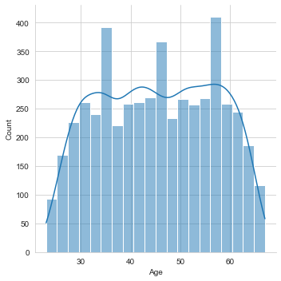

```python
sns.displot(data=bank_master_df, kind='hist', x='Age', kde=True, bins=20)
```

**Observations**

- Age column is normally distributed, although there are multiple modes

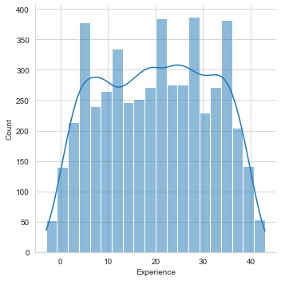

```python
sns.displot(data=bank_master_df, kind='hist', x='Experience', kde=True, bins=20)
```

**Observations**

- Experience column is normally distributed, although there are multiple modes
- 52 rows have negative values for 'Experience' column
- 66 rows have 0 as value for 'Experience' column
- Rows with 0 Experience have Age values between 24 and 30 (both inclusive)
- Negative and 0 values within the column need to be corrected

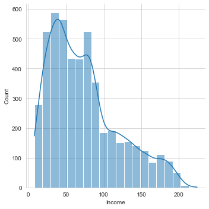

```python
sns.displot(data=bank_master_df, kind='hist', x='Income', kde=True, bins=20)
```

**Observations**

- Income column distribution is right-skewed

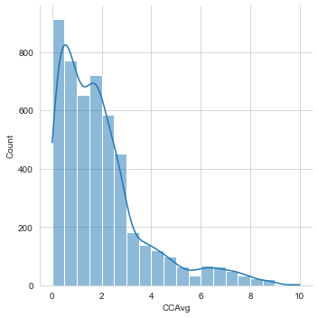

```python
sns.displot(data=bank_master_df, kind='hist', x='CCAvg', kde=True, bins=20)
```

**Observations**

- CCAvg column distribution is right-skewed

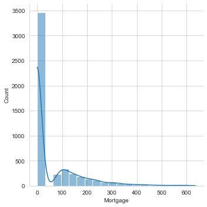

```python
sns.displot(data=bank_master_df, kind='hist', x='Mortgage', kde=True, bins=20)
```

**Observations**

- 3462 rows contain 0 value in 'Mortgage' column

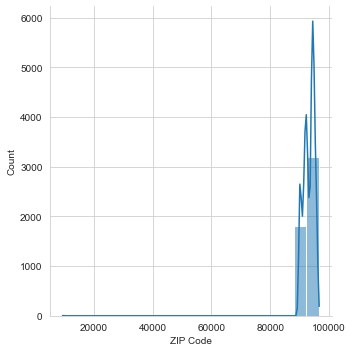

```python
sns.displot(data=bank_master_df, kind='hist', x='ZIP Code', kde=True, bins=20)
```

**Observations**

- ZIP Code column has a row with outlier value of 9307

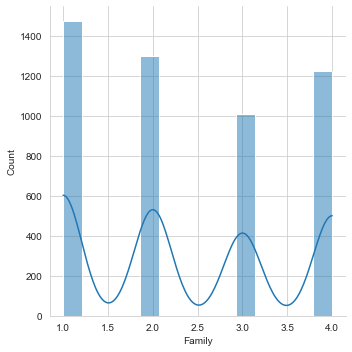

```python
sns.displot(data=bank_master_df, kind='hist', x='Family', kde=True)
```

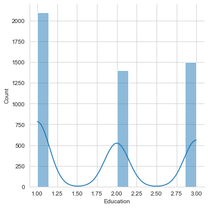

```python
sns.displot(data=bank_master_df, kind='hist', x='Education', kde=True)
```

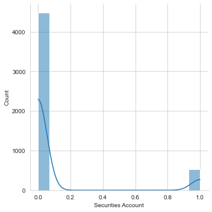

```python
sns.displot(data=bank_master_df, kind='hist', x='Securities Account', kde=True)
```

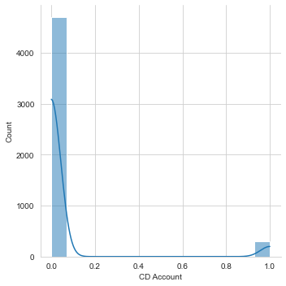

```python
sns.displot(data=bank_master_df, kind='hist', x='CD Account', kde=True)
```

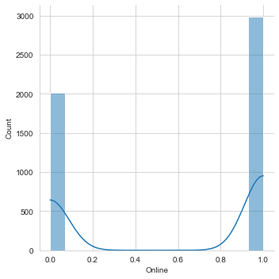

```python
sns.displot(data=bank_master_df, kind='hist', x='Online', kde=True)
```

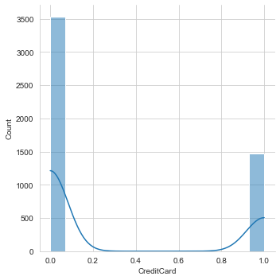

```python
sns.displot(data=bank_master_df, kind='hist', x='CreditCard', kde=True)
```

### Perform data preprocessing based on observations above

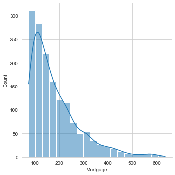

```python
# Redraw the distribution of Mortgage column by eliminating 0 values

mortgage_non_zero_df = bank_master_df.loc[bank_master_df['Mortgage'] != 0]
sns.displot(data=mortgage_non_zero_df, kind='hist', x='Mortgage', kde=True, bins=20)
```

**Observations**

- Mortgage column distribution is right-skewed

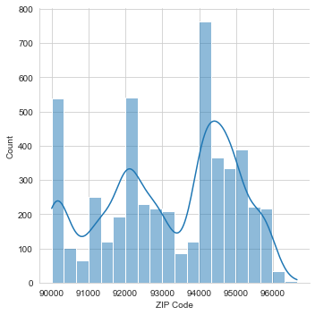

```python
# Redraw the distribution of ZIP Code column by eliminating the row with 9307

zip_code_filtered_df = bank_master_df.loc[bank_master_df['ZIP Code'] != 9307]
sns.displot(data=zip_code_filtered_df, kind='hist', x='ZIP Code', kde=True, bins=20)
```

**Observations**

- ZIP Code column is not normally distributed

```python
# Drop ID column from the dataframe

data_df = bank_master_df.drop('ID', axis='columns')
data_df.columns
```

```
Index(['Age', 'Experience', 'Income', 'ZIP Code', 'Family', 'CCAvg',
       'Education', 'Mortgage', 'Personal Loan', 'Securities Account',
       'CD Account', 'Online', 'CreditCard'],
      dtype='object')
```

```python
data_df.shape
```

```
(5000, 13)
```

```python
data_df.head(10)
```

|  | Age | Experience | Income | ZIP Code | Family | CCAvg | Education | Mortgage | Personal Loan | Securities Account | CD Account | Online | CreditCard |
| --- | --- | --- | --- | --- | --- | --- | --- | --- | --- | --- | --- | --- | --- |
| 0 | 25 | 1 | 49 | 91107 | 4 | 1.6 | 1 | 0 | 0 | 1 | 0 | 0 | 0 |
| 1 | 45 | 19 | 34 | 90089 | 3 | 1.5 | 1 | 0 | 0 | 1 | 0 | 0 | 0 |
| 2 | 39 | 15 | 11 | 94720 | 1 | 1.0 | 1 | 0 | 0 | 0 | 0 | 0 | 0 |
| 3 | 35 | 9 | 100 | 94112 | 1 | 2.7 | 2 | 0 | 0 | 0 | 0 | 0 | 0 |
| 4 | 35 | 8 | 45 | 91330 | 4 | 1.0 | 2 | 0 | 0 | 0 | 0 | 0 | 1 |
| 5 | 37 | 13 | 29 | 92121 | 4 | 0.4 | 2 | 155 | 0 | 0 | 0 | 1 | 0 |
| 6 | 53 | 27 | 72 | 91711 | 2 | 1.5 | 2 | 0 | 0 | 0 | 0 | 1 | 0 |
| 7 | 50 | 24 | 22 | 93943 | 1 | 0.3 | 3 | 0 | 0 | 0 | 0 | 0 | 1 |
| 8 | 35 | 10 | 81 | 90089 | 3 | 0.6 | 2 | 104 | 0 | 0 | 0 | 1 | 0 |
| 9 | 34 | 9 | 180 | 93023 | 1 | 8.9 | 3 | 0 | 1 | 0 | 0 | 0 | 0 |

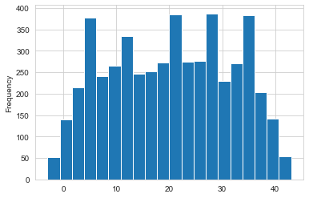

```python
# Plot distribution of Experience column before pre-processing. Observe negative and zero values

data_df['Experience'].plot(kind='hist', bins=20)
# sns.displot(data=data_df, kind='hist', x='Experience', kde=True, bins=20)
```

```python
# Replace negative values in Experience column with positive values

print('Count of negative value rows (before replacement):', len(data_df[data_df['Experience'] < 0]))

data_df['Experience'].replace({-1: 1, -2: 2, -3: 3}, inplace=True)

print('Count of negative value rows (after replacement):', len(data_df[data_df['Experience'] < 0]))
```

```
Count of negative value rows (before replacement): 52
Count of negative value rows (after replacement): 0
```

```python
# Replace 0 values in Experience column with random non zero values based on Mean and Standard Deviation of Age between 24 and 30

experience_mean = data_df['Experience'].loc[(data_df['Age'] >= 24) & (data_df['Age'] <= 30) ].mean()
experience_std = data_df['Experience'].loc[(data_df['Age'] >= 24) & (data_df['Age'] <= 30) ].std()
experience_zero_count = len(data_df[data_df['Experience'] == 0])

print('Mean:', experience_mean)
print('Std. Dev.:', experience_std)
print('Zero Count: (before replacement)', experience_zero_count)

if experience_zero_count > 0:
    rand_exp = np.random.randint(experience_mean - experience_std, experience_mean + experience_std, size=experience_zero_count)

    print('Experience array:', rand_exp)
    print('Experience array length:', len(rand_exp))

    data_df.loc[data_df['Experience'] == 0, 'Experience'] = rand_exp

    print('Zero Count (after replacement):', len(data_df[data_df['Experience'] == 0]))
```

```
Mean: 2.8627450980392157
Std. Dev.: 1.758063298099139
Zero Count: (before replacement) 66
Experience array: [2 2 3 3 1 2 3 2 2 1 2 1 1 2 1 1 3 2 3 3 3 1 2 2 1 1 2 1 1 1 2 1 3 2 2 1 2
 2 2 1 1 1 1 1 3 1 3 1 3 3 1 2 1 3 3 3 1 3 2 1 2 1 1 3 1 2]
Experience array length: 66
Zero Count (after replacement): 0
```

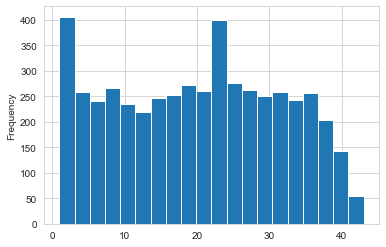

```python
# Plot distribution of Experience column after pre-processing. Observe negative and zero values have been removed

data_df['Experience'].plot(kind='hist', bins=20)
# sns.displot(data=data_df, kind='hist', x='Experience', kde=True, bins=20)
```

## 3. Get the target column distribution. Your comments (5 marks)

```python
data_df['Personal Loan'].value_counts()
```

```
0    4520
1     480
Name: Personal Loan, dtype: int64
```

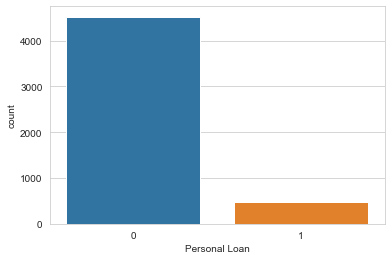

```python
sns.countplot(data=data_df, x='Personal Loan')
```

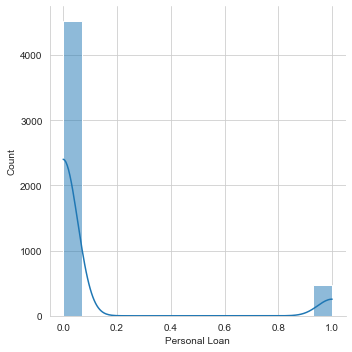

```python
sns.displot(data=data_df, kind='hist', x='Personal Loan', kde=True)
```

**Observations**

- Number of people who have taken personal loan is significantly less than those who have not taken personal loan

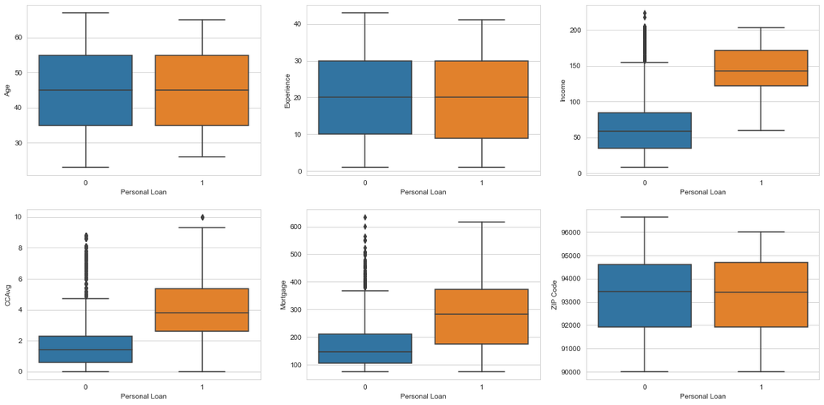

```python
plt.figure(figsize=(20, 15))

plt.subplot(3, 3, 1)
sns.boxplot(x='Personal Loan', y='Age', data=data_df)

plt.subplot(3, 3, 2)
sns.boxplot(x='Personal Loan', y='Experience', data=data_df)

plt.subplot(3, 3, 3)
sns.boxplot(x='Personal Loan', y='Income', data=data_df)

plt.subplot(3, 3, 4)
sns.boxplot(x='Personal Loan', y='CCAvg', data=data_df)

plt.subplot(3, 3, 5)
sns.boxplot(x='Personal Loan', y='Mortgage', data=mortgage_non_zero_df)

plt.subplot(3, 3, 6)
sns.boxplot(x='Personal Loan', y='ZIP Code', data=zip_code_filtered_df)
```

**Observations**

- Income, CCAvg and Mortgage columns have outliers and thus they are right-skewed
- People with higher Income, CCAvg and Mortgage have taken Personal Loan

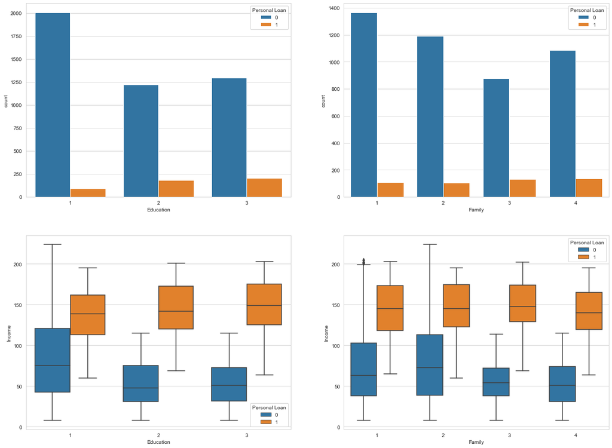

```python
plt.figure(figsize=(20, 15))

plt.subplot(2, 2, 1)
sns.countplot(x='Education', data=data_df, hue='Personal Loan')

plt.subplot(2, 2, 2)
sns.countplot(x='Family', data=data_df, hue='Personal Loan')

plt.subplot(2, 2, 3)
sns.boxplot(x='Education', y='Income', data=data_df, hue='Personal Loan')

plt.subplot(2, 2, 4)
sns.boxplot(x='Family', y='Income', data=data_df, hue='Personal Loan')
```

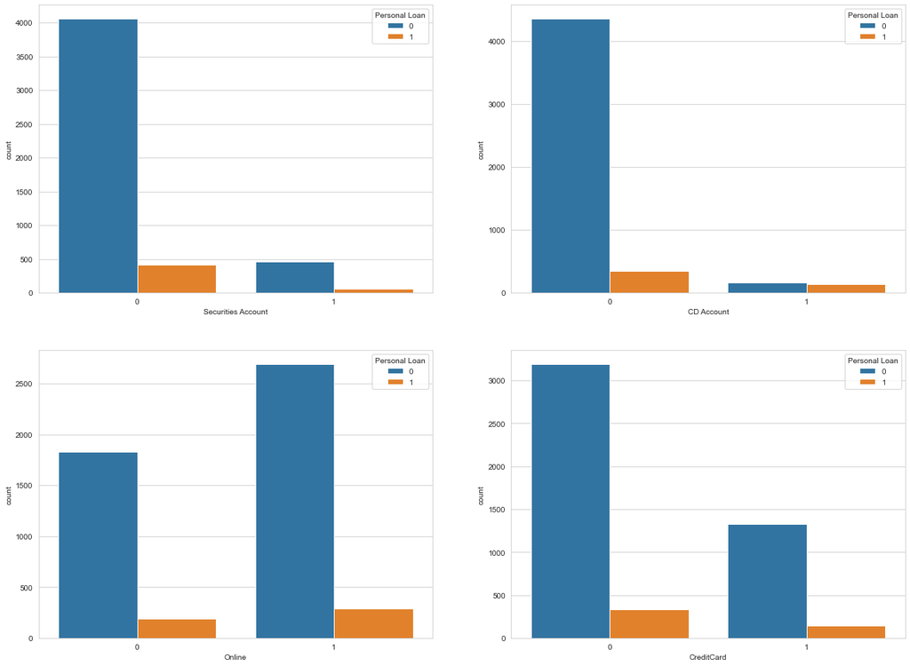

```python
plt.figure(figsize=(20, 15))

plt.subplot(2, 2, 1)
sns.countplot(x='Securities Account', data=data_df, hue='Personal Loan')

plt.subplot(2, 2, 2)
sns.countplot(x='CD Account', data=data_df, hue='Personal Loan')

plt.subplot(2, 2, 3)
sns.countplot(x='Online', data=data_df, hue='Personal Loan')

plt.subplot(2, 2, 4)
sns.countplot(x='CreditCard', data=data_df, hue='Personal Loan')
```

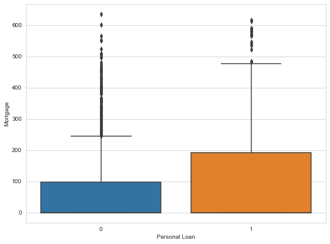

```python
plt.figure(figsize=(20, 15))

plt.subplot(2, 2, 1)
sns.boxplot(x='Personal Loan', y='Mortgage', data=data_df)
```

**Observations**

- The customers who have taken the Personal Loan have high Mortgage than customers who have not taken the Personal Loan

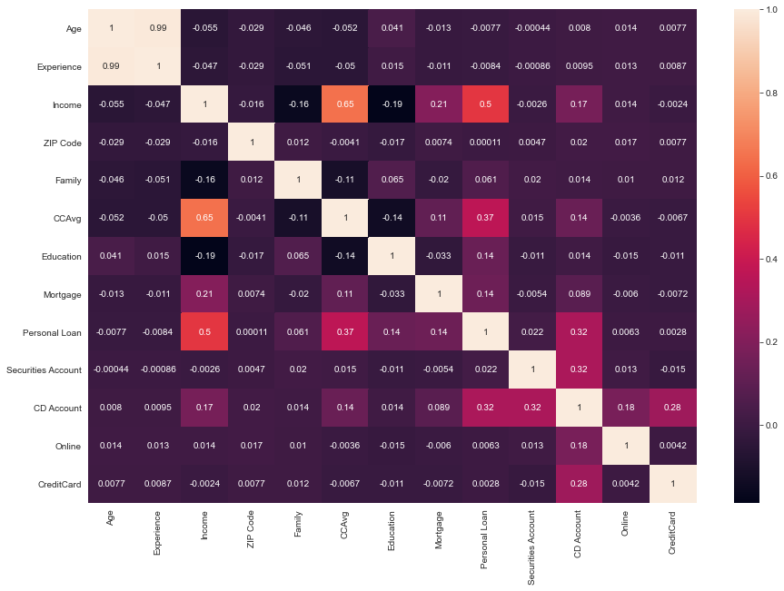

```python
corr = data_df.corr()
plt.figure(figsize=(15, 10))
sns.heatmap(corr, annot=True)
```

**Observations**

- We can see that the Experience and Age are highly correlated. Hence we can drop one of them
- We can see from above correlation that Income (50%), CCAvg (37%), CD Account (32%) are more correlated to the Personal Loan, making them more important for the model

```python
# Checking for multicollinearity using Variance Inflation Factor

from statsmodels.stats.outliers_influence import variance_inflation_factor

vif = pd.DataFrame()
vif['VIF Factor'] = [variance_inflation_factor(data_df.values, i) for i in range(data_df.shape[1])]
vif['Features'] = data_df.columns
vif
```

|  | VIF Factor | Features |
| --- | --- | --- |
| 0 | 1206.720996 | Age |
| 1 | 302.727390 | Experience |
| 2 | 7.861890 | Income |
| 3 | 343.516798 | ZIP Code |
| 4 | 5.675816 | Family |
| 5 | 3.868361 | CCAvg |
| 6 | 7.130221 | Education |
| 7 | 1.376914 | Mortgage |
| 8 | 1.799164 | Personal Loan |
| 9 | 1.276620 | Securities Account |
| 10 | 1.538028 | CD Account |
| 11 | 2.586640 | Online |
| 12 | 1.580196 | CreditCard |

**Observations**

- We can observe that Variance Inflation Factor (VIF) is very high for Age, Experience and ZIP Code columns. This denotes high multicollinearity between independent variables. Therefore we can remove either Experience or Age from the dataset. However VIF of Age is higher, so we will consider removing it. We will also remove ZIP Code column

```python
# Let us drop Age and ZIP Code columns

data_df.drop(['Age', 'ZIP Code'], axis='columns', inplace=True)
```

```python
# Checking for multicollinearity using Variance Inflation Factor after removing Age and ZIP Code columns

vif = pd.DataFrame()
vif['VIF Factor'] = [variance_inflation_factor(data_df.values, i) for i in range(data_df.shape[1])]
vif['Features'] = data_df.columns
vif
```

|  | VIF Factor | Features |
| --- | --- | --- |
| 0 | 3.489965 | Experience |
| 1 | 6.233378 | Income |
| 2 | 4.109345 | Family |
| 3 | 3.838794 | CCAvg |
| 4 | 4.449351 | Education |
| 5 | 1.371069 | Mortgage |
| 6 | 1.611251 | Personal Loan |
| 7 | 1.264506 | Securities Account |
| 8 | 1.528257 | CD Account |
| 9 | 2.429081 | Online |
| 10 | 1.545189 | CreditCard |

```python
data_df.info()
```

```
<class 'pandas.core.frame.DataFrame'>
RangeIndex: 5000 entries, 0 to 4999
Data columns (total 11 columns):
 #   Column              Non-Null Count  Dtype
---  ------              --------------  -----
 0   Experience          5000 non-null   int64
 1   Income              5000 non-null   int64
 2   Family              5000 non-null   int64
 3   CCAvg               5000 non-null   float64
 4   Education           5000 non-null   int64
 5   Mortgage            5000 non-null   int64
 6   Personal Loan       5000 non-null   int64
 7   Securities Account  5000 non-null   int64
 8   CD Account          5000 non-null   int64
 9   Online              5000 non-null   int64
 10  CreditCard          5000 non-null   int64
dtypes: float64(1), int64(10)
memory usage: 429.8 KB
```

```python
data_df.columns
```

```
Index(['Experience', 'Income', 'Family', 'CCAvg', 'Education', 'Mortgage',
       'Personal Loan', 'Securities Account', 'CD Account', 'Online',
       'CreditCard'],
      dtype='object')
```

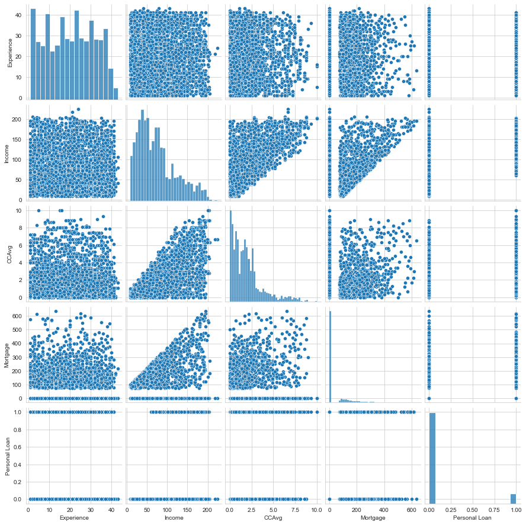

```python
partial_data_df_1 = data_df.drop(['Family', 'Education', 'Securities Account', 'CD Account', 'Online', 'CreditCard'], axis='columns')
sns.pairplot(partial_data_df_1)
```

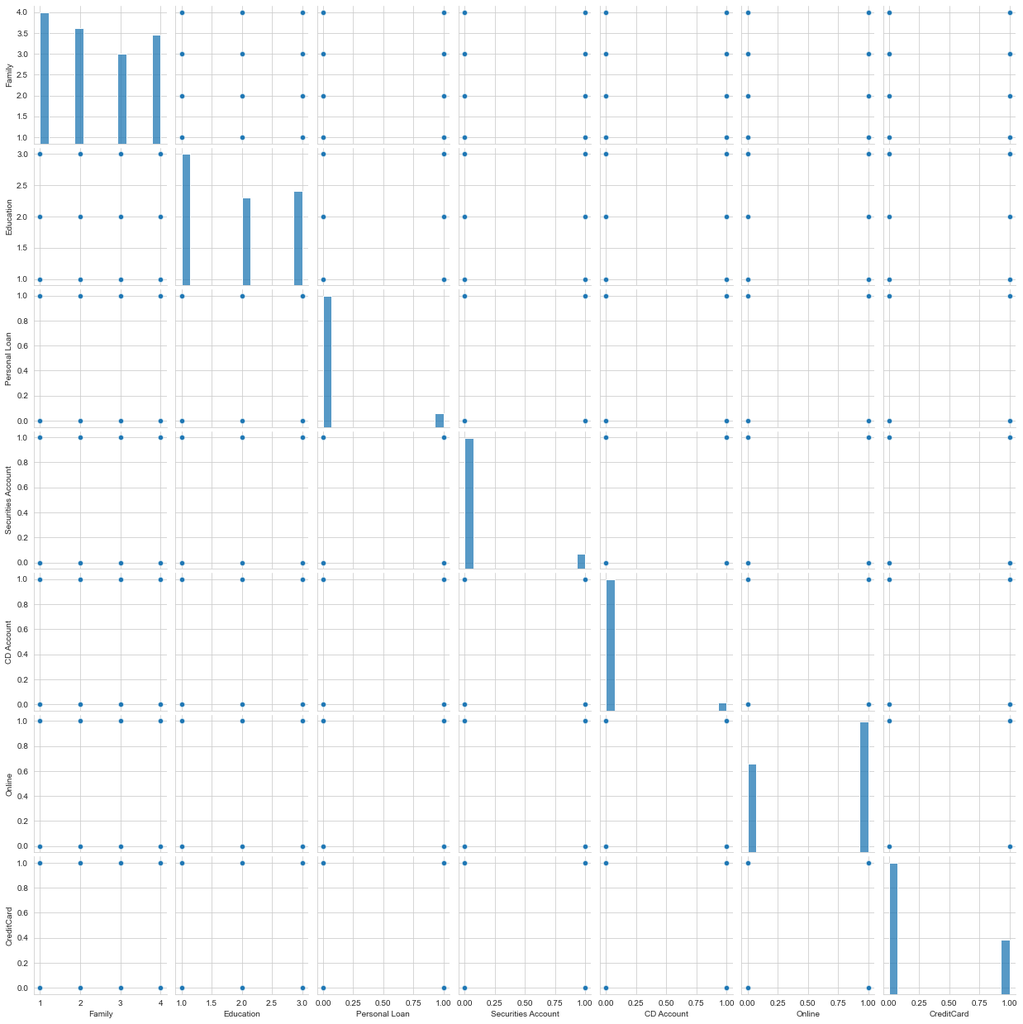

```python
partial_data_df_2 = data_df.drop(['Experience', 'Income', 'CCAvg', 'Mortgage'], axis='columns')
sns.pairplot(partial_data_df_2)
```

## 4. Split the data into training and test set in the ratio of 70:30 respectively (5 marks)

### Perform data pre-processing

```python
from sklearn import preprocessing
from sklearn.model_selection import train_test_split
```

```python
# Convert Education (Categorical) column into dummy/indicator variables

model_data_df = pd.get_dummies(data_df, columns=['Education'], drop_first=True)
model_data_df.head()
```

|  | Experience | Income | Family | CCAvg | Mortgage | Personal Loan | Securities Account | CD Account | Online | CreditCard | Education_2 | Education_3 |
| --- | --- | --- | --- | --- | --- | --- | --- | --- | --- | --- | --- | --- |
| 0 | 1 | 49 | 4 | 1.6 | 0 | 0 | 1 | 0 | 0 | 0 | 0 | 0 |
| 1 | 19 | 34 | 3 | 1.5 | 0 | 0 | 1 | 0 | 0 | 0 | 0 | 0 |
| 2 | 15 | 11 | 1 | 1.0 | 0 | 0 | 0 | 0 | 0 | 0 | 0 | 0 |
| 3 | 9 | 100 | 1 | 2.7 | 0 | 0 | 0 | 0 | 0 | 0 | 1 | 0 |
| 4 | 8 | 45 | 4 | 1.0 | 0 | 0 | 0 | 0 | 0 | 1 | 1 | 0 |

```python
model_data_df.columns
```

```
Index(['Experience', 'Income', 'Family', 'CCAvg', 'Mortgage', 'Personal Loan',
       'Securities Account', 'CD Account', 'Online', 'CreditCard',
       'Education_2', 'Education_3'],
      dtype='object')
```

```python
# Normalize the dataset using Scaler object, here let us consider MinMaxScaler

scaler = preprocessing.MinMaxScaler()
scaler_result = scaler.fit_transform(model_data_df)

scaled_model_data_df = pd.DataFrame(scaler_result, columns=list(model_data_df.columns))
scaled_model_data_df.head()
```

|  | Experience | Income | Family | CCAvg | Mortgage | Personal Loan | Securities Account | CD Account | Online | CreditCard | Education_2 | Education_3 |
| --- | --- | --- | --- | --- | --- | --- | --- | --- | --- | --- | --- | --- |
| 0 | 0.000000 | 0.189815 | 1.000000 | 0.16 | 0.0 | 0.0 | 1.0 | 0.0 | 0.0 | 0.0 | 0.0 | 0.0 |
| 1 | 0.428571 | 0.120370 | 0.666667 | 0.15 | 0.0 | 0.0 | 1.0 | 0.0 | 0.0 | 0.0 | 0.0 | 0.0 |
| 2 | 0.333333 | 0.013889 | 0.000000 | 0.10 | 0.0 | 0.0 | 0.0 | 0.0 | 0.0 | 0.0 | 0.0 | 0.0 |
| 3 | 0.190476 | 0.425926 | 0.000000 | 0.27 | 0.0 | 0.0 | 0.0 | 0.0 | 0.0 | 0.0 | 1.0 | 0.0 |
| 4 | 0.166667 | 0.171296 | 1.000000 | 0.10 | 0.0 | 0.0 | 0.0 | 0.0 | 0.0 | 1.0 | 1.0 | 0.0 |

```python
# scaler = preprocessing.StandardScaler()
# scaler_result = scaler.fit_transform(model_data_df)

# scaled_model_data_df = pd.DataFrame(scaler_result, columns=list(model_data_df.columns))
# scaled_model_data_df.head()
```

```python
features = ['Experience', 'Income', 'Family', 'CCAvg', 'Mortgage', 'Securities Account', 'CD Account',
            'Online', 'CreditCard', 'Education_2', 'Education_3']
X = scaled_model_data_df[features]
y = scaled_model_data_df['Personal Loan']
```

```python
X_train, X_test, y_train, y_test = train_test_split(X, y, test_size=0.3, random_state=10)
```

```python
X_train.info()
```

```
<class 'pandas.core.frame.DataFrame'>
Int64Index: 3500 entries, 2573 to 1289
Data columns (total 11 columns):
 #   Column              Non-Null Count  Dtype
---  ------              --------------  -----
 0   Experience          3500 non-null   float64
 1   Income              3500 non-null   float64
 2   Family              3500 non-null   float64
 3   CCAvg               3500 non-null   float64
 4   Mortgage            3500 non-null   float64
 5   Securities Account  3500 non-null   float64
 6   CD Account          3500 non-null   float64
 7   Online              3500 non-null   float64
 8   CreditCard          3500 non-null   float64
 9   Education_2         3500 non-null   float64
 10  Education_3         3500 non-null   float64
dtypes: float64(11)
memory usage: 328.1 KB
```

```python
X_train.head()
```

|  | Experience | Income | Family | CCAvg | Mortgage | Securities Account | CD Account | Online | CreditCard | Education_2 | Education_3 |
| --- | --- | --- | --- | --- | --- | --- | --- | --- | --- | --- | --- |
| 2573 | 0.785714 | 0.333333 | 0.333333 | 0.16 | 0.000000 | 0.0 | 0.0 | 1.0 | 1.0 | 0.0 | 0.0 |
| 2066 | 0.357143 | 0.101852 | 0.333333 | 0.14 | 0.000000 | 0.0 | 0.0 | 0.0 | 1.0 | 1.0 | 0.0 |
| 2823 | 0.142857 | 0.060185 | 0.000000 | 0.06 | 0.000000 | 1.0 | 0.0 | 0.0 | 0.0 | 0.0 | 1.0 |
| 2389 | 0.000000 | 0.152778 | 0.000000 | 0.19 | 0.000000 | 0.0 | 0.0 | 0.0 | 1.0 | 0.0 | 1.0 |
| 2702 | 0.404762 | 0.629630 | 0.333333 | 0.61 | 0.248819 | 0.0 | 0.0 | 0.0 | 0.0 | 0.0 | 0.0 |

```python
y_train.count()
```

```
3500
```

```python
X_test.info()
```

```
<class 'pandas.core.frame.DataFrame'>
Int64Index: 1500 entries, 245 to 1555
Data columns (total 11 columns):
 #   Column              Non-Null Count  Dtype
---  ------              --------------  -----
 0   Experience          1500 non-null   float64
 1   Income              1500 non-null   float64
 2   Family              1500 non-null   float64
 3   CCAvg               1500 non-null   float64
 4   Mortgage            1500 non-null   float64
 5   Securities Account  1500 non-null   float64
 6   CD Account          1500 non-null   float64
 7   Online              1500 non-null   float64
 8   CreditCard          1500 non-null   float64
 9   Education_2         1500 non-null   float64
 10  Education_3         1500 non-null   float64
dtypes: float64(11)
memory usage: 140.6 KB
```

```python
X_test.head()
```

|  | Experience | Income | Family | CCAvg | Mortgage | Securities Account | CD Account | Online | CreditCard | Education_2 | Education_3 |
| --- | --- | --- | --- | --- | --- | --- | --- | --- | --- | --- | --- |
| 245 | 0.238095 | 0.078704 | 0.333333 | 0.10 | 0.000000 | 0.0 | 0.0 | 0.0 | 0.0 | 1.0 | 0.0 |
| 4493 | 0.642857 | 0.305556 | 0.000000 | 0.26 | 0.000000 | 0.0 | 0.0 | 1.0 | 1.0 | 1.0 | 0.0 |
| 4583 | 0.595238 | 0.347222 | 0.000000 | 0.31 | 0.000000 | 0.0 | 0.0 | 1.0 | 0.0 | 0.0 | 0.0 |
| 2242 | 0.380952 | 0.171296 | 0.000000 | 0.18 | 0.270866 | 1.0 | 0.0 | 1.0 | 0.0 | 0.0 | 0.0 |
| 3407 | 0.738095 | 0.050926 | 1.000000 | 0.07 | 0.000000 | 0.0 | 0.0 | 0.0 | 0.0 | 0.0 | 1.0 |

```python
y_test.count()
```

```
1500
```

## 5. Use different classification models (Logistic, K-NN and Naïve Bayes) to predict the likelihood of a customer buying personal loans (15 marks)

## 6. Print the confusion matrix for all the models (5 marks)

```python
# Import the required classifiers and metrics related api for different models under consideration

from sklearn.linear_model import LogisticRegression
from sklearn.neighbors import KNeighborsClassifier
from sklearn.naive_bayes import GaussianNB

from sklearn.metrics import confusion_matrix, accuracy_score, classification_report, roc_auc_score, roc_curve
```

### Choosing a K Value for K-Nearest Neighbor

Let's go ahead and choose a good K Value. Choosing the right k is not easy and is subjective. Usually an odd number is chosen. A small K captures too much training noise and hence does not do well in test data. A very large K does so much smoothening that it does not manage to capture information in the training data sufficiently and hence does not do well in test data. If the number of classes is 2, many suggest a rule of thumb approach (set k=sqrt(n)), that might not be the best but does well mostly.

#### Method 1

```python
scores = []
for k in range(1, 11):
    model = KNeighborsClassifier(n_neighbors=k, weights='distance' )
    model.fit(X_train, y_train)
    scores.append(model.score(X_test, y_test))
```

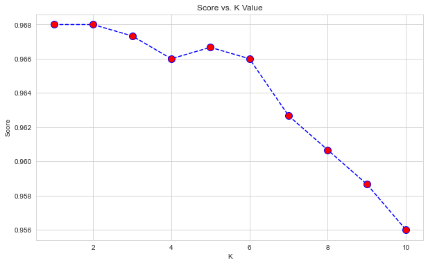

```python
plt.figure(figsize=(10, 6))

plt.plot(range(1, 11), scores, color='blue', linestyle='dashed', marker='o',
         markerfacecolor='red', markersize=10)

plt.title('Score vs. K Value')
plt.xlabel('K')
plt.ylabel('Score')
```

#### Method 2

```python
error_rates = []
for i in range(1, 11):
    model = KNeighborsClassifier(n_neighbors=i)
    model.fit(X_train, y_train)
    pred_i = model.predict(X_test)
    error_rates.append(np.mean(pred_i != y_test))
```

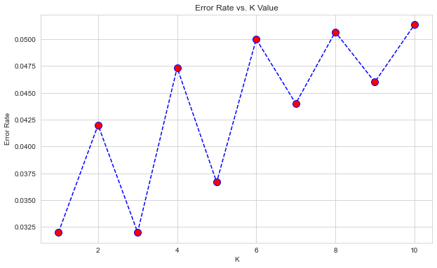

```python
plt.figure(figsize=(10, 6))

plt.plot(range(1, 11), error_rates, color='blue', linestyle='dashed', marker='o',
         markerfacecolor='red', markersize=10)

plt.title('Error Rate vs. K Value')
plt.xlabel('K')
plt.ylabel('Error Rate')
```

**Observations**

- Method 1 suggests K value to be 1 or 2 for high accuracy score
- Method 2 suggests K value to be 3 for low error rate

**We will consider K value of 3 for optimum accuracy score and low error rate**

### Reusable functions for Train & Predict and printing metrics

```python
def train_and_predict(model_name, model, X_train, y_train, X_test, y_test):
    print(f'MODEL: {model_name}\n')

    model.fit(X_train, y_train)
    y_pred = model.predict(X_test)

    score_train = model.score(X_train, y_train)
    print(f'Mean Accuracy Score (Train): {score_train}')

    score_test = model.score(X_test, y_test)
    print(f'Mean Accuracy Score (Test): {score_test}')

    roc_auc = roc_auc_score(y_test, y_pred)
    fpr, tpr, threshold = roc_curve(y_test, model.predict_proba(X_test)[:,1])
    print(f'ROC AUC Score: {roc_auc}\n')

    return (y_pred, roc_auc, fpr, tpr)

def show_metrics(model_name, y_test, y_pred):
    accuracy = round(accuracy_score(y_test, y_pred), 2) * 100
    print(f'Accuracy: {accuracy}\n')

    print('---------------------')
    print('Classification Report')
    print('---------------------')
    print(classification_report(y_test, y_pred))

    print('----------------')
    print('Confusion Matrix')
    print('----------------')
    cm = confusion_matrix(y_test, y_pred)
    print(cm)
    sns.heatmap(cm, annot=True, fmt='g', cbar=False, cmap='YlOrRd')
```

### 5.1. Logistic Regression

```
MODEL: Logistic Regression

Mean Accuracy Score (Train): 0.952
Mean Accuracy Score (Test): 0.9573333333333334
ROC AUC Score: 0.7970588235294118

Accuracy: 96.0

---------------------
Classification Report
---------------------
              precision    recall  f1-score   support

         0.0       0.96      0.99      0.98      1360
         1.0       0.91      0.60      0.72       140

    accuracy                           0.96      1500
   macro avg       0.94      0.80      0.85      1500
weighted avg       0.96      0.96      0.95      1500

----------------
Confusion Matrix
----------------
[[1352    8]
 [  56   84]]
```

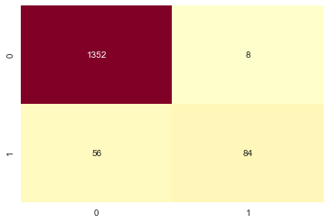

```python
model_lr = LogisticRegression(solver='liblinear')
y_pred, roc_auc_lr, fpr_lr, tpr_lr = train_and_predict('Logistic Regression', model_lr, X_train, y_train, X_test, y_test)
show_metrics('Logistic Regression', y_test, y_pred)
```

### 5.2. K-Nearest Neighbor

```
MODEL: K-Nearest Neighbor

Mean Accuracy Score (Train): 1.0
Mean Accuracy Score (Test): 0.9673333333333334
ROC AUC Score: 0.8634453781512605

Accuracy: 97.0

---------------------
Classification Report
---------------------
              precision    recall  f1-score   support

         0.0       0.97      0.99      0.98      1360
         1.0       0.90      0.74      0.81       140

    accuracy                           0.97      1500
   macro avg       0.93      0.86      0.89      1500
weighted avg       0.97      0.97      0.97      1500

----------------
Confusion Matrix
----------------
[[1348   12]
 [  37  103]]
```

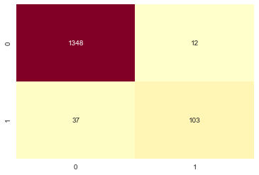

```python
model_knn = KNeighborsClassifier(weights='distance', n_neighbors=3)
y_pred, roc_auc_knn, fpr_knn, tpr_knn = train_and_predict('K-Nearest Neighbor', model_knn, X_train, y_train, X_test, y_test)
show_metrics('K-Nearest Neighbor', y_test, y_pred)
```

### 5.3. Naive Bayes

```
MODEL: Naive Bayes

Mean Accuracy Score (Train): 0.8825714285714286
Mean Accuracy Score (Test): 0.8806666666666667
ROC AUC Score: 0.757983193277311

Accuracy: 88.0

---------------------
Classification Report
---------------------
              precision    recall  f1-score   support

         0.0       0.96      0.91      0.93      1360
         1.0       0.41      0.61      0.49       140

    accuracy                           0.88      1500
   macro avg       0.68      0.76      0.71      1500
weighted avg       0.91      0.88      0.89      1500

----------------
Confusion Matrix
----------------
[[1236  124]
 [  55   85]]
```

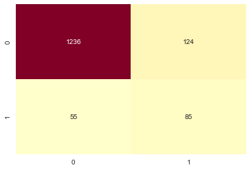

```python
model_nb = GaussianNB()
y_pred, roc_auc_nb, fpr_nb, tpr_nb = train_and_predict('Naive Bayes', model_nb, X_train, y_train, X_test, y_test)
show_metrics('Naive Bayes', y_test, y_pred)
```

## 7. Give your reasoning on which is the best model in this case and why it performs better? (5 marks)

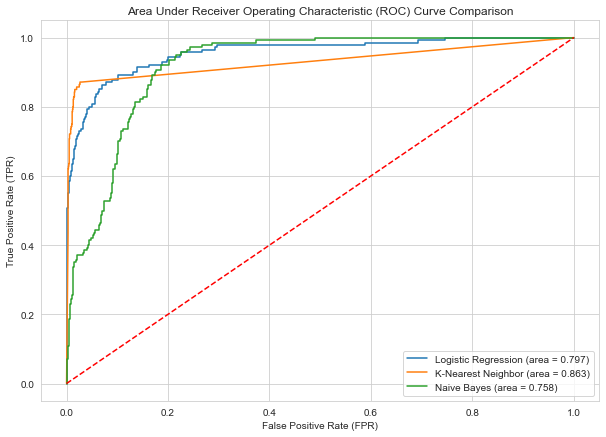

```python
# Plot ROC AUC curve for all model predictions and compare them
plt.figure(figsize=(10,7))

plt.plot(fpr_lr, tpr_lr, label='Logistic Regression (area = %0.3f)' % roc_auc_lr)
plt.plot(fpr_knn, tpr_knn, label='K-Nearest Neighbor (area = %0.3f)' % roc_auc_knn)
plt.plot(fpr_nb, tpr_nb, label='Naive Bayes (area = %0.3f)' % roc_auc_nb)
plt.plot([0, 1], [0, 1],'r--')

plt.xlabel('False Positive Rate (FPR)')
plt.ylabel('True Positive Rate (TPR)')

plt.title('Area Under Receiver Operating Characteristic (ROC) Curve Comparison')
plt.legend(loc="lower right")
```

**Observations & Conclusion**